# Univariate Data

true

2018

# Three types of data:

- Categorical
- Numeric
- - Discrete numeric
- - Continuous numeric

Methods for viewing and summarizing the data depend on the type.

## Categorical data

Data that records categories Examples: * Hair color * Eye color * Computer brand

## Discrete numeric quantities:

Examples: * Age of a person - 10, 22, 50, 73 * Weight - 50, 60, 62

## Continuous numeric quantities:

- Height - 1.60, 1.62, 1.70, 1.80

# Methods for viewing data

## Categorical

### table()

### prop.table()

### bar graphs

### pie charts

## Numeric

### summary()

### fivenum()

### Measures of center and spread

#### Center

##### mean

##### trimmed mean

- useful if the data has many outliers

  ```
  x = c(-100, 0, 10, 10000)
  mean(x, trim = 1/10)
  ```

  We trim off 1/10 from the top and the bottom and then take the average As we trim more and more, the value of the mean gets closer to the median which is when trim = 1/2

##### median

Indifferent for larger values…

#### Spread

##### standard deviation

sensitive to outliers

##### variance

sensitive to outliers

##### IQR(interquartile range)

difference of the 3rd and 1st quantile

##### mad (median average deviation)

finds the median of the absolute differences from the median and then multiplies by a constant. median|X_i - median(X)| (1.4826)

### stem-and-leaf charts

for small data sets, for seeing the shape of the distribution and the values

### hist

### boxplot

### density

### polygon

# Tasks - moodle

Разглеждаме данните ‘survey’ от пакета “MASS’.

```r
# install.packages("MASS")
library(MASS)
names(survey)
```

```
 [1] "Sex"    "Wr.Hnd" "NW.Hnd" "W.Hnd"  "Fold"   "Pulse"  "Clap"   "Exer"   "Smoke"  "Height"
[11] "M.I"    "Age"
```

```r
summary(survey)
```

```
     Sex          Wr.Hnd         NW.Hnd       W.Hnd          Fold         Pulse
 Female:118   Min.   :13.0   Min.   :12.5   Left : 18   L on R : 99   Min.   : 35.0
 Male  :118   1st Qu.:17.5   1st Qu.:17.5   Right:218   Neither: 18   1st Qu.: 66.0
 NA's  :  1   Median :18.5   Median :18.5   NA's :  1   R on L :120   Median : 72.5
              Mean   :18.7   Mean   :18.6                             Mean   : 74.2
              3rd Qu.:19.8   3rd Qu.:19.7                             3rd Qu.: 80.0
              Max.   :23.2   Max.   :23.5                             Max.   :104.0
              NA's   :1      NA's   :1                                NA's   :45
      Clap       Exer       Smoke         Height          M.I           Age
 Left   : 39   Freq:115   Heavy: 11   Min.   :150   Imperial: 68   Min.   :16.8
 Neither: 50   None: 24   Never:189   1st Qu.:165   Metric  :141   1st Qu.:17.7
 Right  :147   Some: 98   Occas: 19   Median :171   NA's    : 28   Median :18.6
 NA's   :  1              Regul: 17   Mean   :172                  Mean   :20.4
                          NA's :  1   3rd Qu.:180                  3rd Qu.:20.2
                                      Max.   :200                  Max.   :73.0
                                      NA's   :28
```

```r
View(survey)
?survey
```

## Задача 1

Въз основа на данните пресметнете вероятноститте:

а) Случайно избран човек да се окаже редовен пушач. P(Smoke = “Regul”) = ?

```r
length = length(survey$Smoke) - sum(is.na(survey$Smoke))
P.Regul = sum(survey$Smoke == "Regul", na.rm = TRUE) / length
P.Regul
```

```
[1] 0.072
```

```r
prop.table(table(survey$Smoke))
```

```
 Heavy  Never  Occas  Regul
0.0466 0.8008 0.0805 0.0720
```

```r
prop.table(table(survey$Smoke))["Regul"]
```

```
Regul
0.072
```

б) Случиайно избран човек да се окаже редовно пушещ мъж. P(Smoke = “Regul” & Sex = “Male”) = ?

```r
length = length(survey$Smoke) - sum(is.na(survey$Smoke) | is.na(survey$Sex))
P.RegulANDsmoke = sum(survey$Smoke == "Regul" & survey$Sex == "Male", na.rm = TRUE) / length
P.RegulANDsmoke
```

```
[1] 0.0511
```

```r
prop.table(table(survey$Smoke, survey$Sex))
```

```
        Female   Male
  Heavy 0.0213 0.0255
  Never 0.4213 0.3787
  Occas 0.0383 0.0426
  Regul 0.0213 0.0511
```

```r
prop.table(table(survey$Smoke, survey$Sex))["Regul", "Male"]
```

```
[1] 0.0511
```

в) Случайно избран мъж да се окаже редовен пушач P(Smoke = “Regul” | Sex = “Male”) = P(Smoke = “Regul” & Sex = “Male”) / P(Sex = “Male”) = ?

```r
length = length(survey$Sex) - sum(is.na(survey$Sex))
P.Male = sum(survey$Sex == "Male", na.rm = TRUE) / length
P.RegulANDsmoke / P.Male
```

```
[1] 0.102
```

```r
prop.table(table(survey$Sex, survey$Smoke), 1)
```

```
          Heavy  Never  Occas  Regul
  Female 0.0424 0.8390 0.0763 0.0424
  Male   0.0513 0.7607 0.0855 0.1026
```

```r
prop.table(table(survey$Sex, survey$Smoke), 1)["Male", "Regul"]
```

```
[1] 0.103
```

Г) Случайно избран редовен пушач да се окаже мъж P(Sex = “Male” | Smoke = “Regul”) = P(Sex = “Male” & Smoke = “Regul”) / P(Smoke = “Regul”) = ?

```r
P.RegulANDsmoke / P.Regul
```

```
[1] 0.709
```

```r
prop.table(table(survey$Sex, survey$Smoke), 2)
```

```
         Heavy Never Occas Regul
  Female 0.455 0.527 0.474 0.294
  Male   0.545 0.473 0.526 0.706
```

```r
prop.table(table(survey$Sex, survey$Smoke), 2)["Male", "Regul"]
```

```
[1] 0.706
```

## Задача 2

Представете графично данните за тютюнопушенето на студентите. А също и за тютюнпушенето в зависимост от пола.  
Данните за тютюнопушенето са:

```r
summary(survey$Smoke)
```

```
Heavy Never Occas Regul  NA's
   11   189    19    17     1
```

Данните са качествени. Следователно може да разгледаме честотната им таблица и графиките.

```r
table(survey$Smoke, useNA = "ifany")
```

```
Heavy Never Occas Regul  <NA>
   11   189    19    17     1
```

```r
prop.table(table(survey$Smoke, useNA = "ifany"))
```

```
  Heavy   Never   Occas   Regul    <NA>
0.04641 0.79747 0.08017 0.07173 0.00422
```

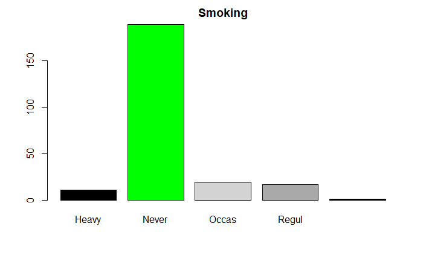

```r
barplot(table(survey$Smoke, useNA = "ifany"),
        main = "Smoking",
        col = c("black", "green", "lightgrey", "darkgrey"))
```

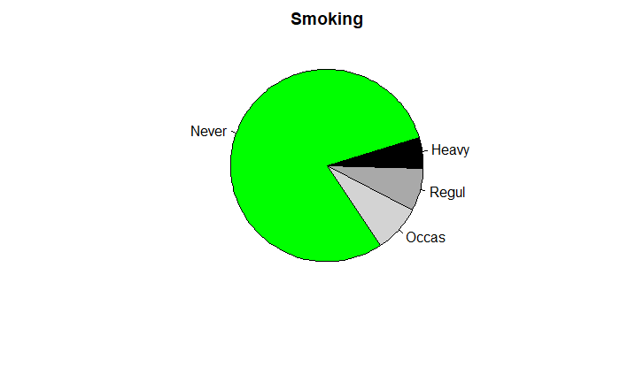

```r
pie(table(survey$Smoke, useNA = "ifany"),
    main = "Smoking",
    col = c("black", "green", "lightgrey", "darkgrey"))
```

Също така можем да използваме:

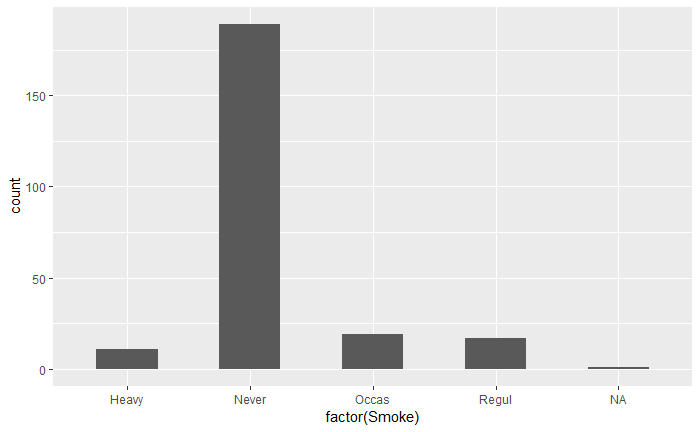

```r
# install.packages("ggplot2")
library(ggplot2)
ggplot(data = survey, aes(x = factor(Smoke))) +
  geom_bar(stat = "count", width=0.5)
```

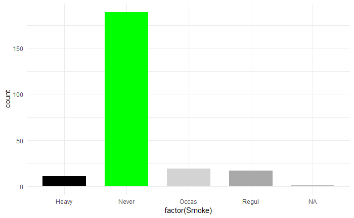

```r
ggplot(data = survey, aes(x = factor(Smoke))) +
  geom_bar(stat = "count", width = 0.7,
           fill = c("black", "green", "lightgrey", "darkgrey", "grey")) +
  theme_minimal()
```

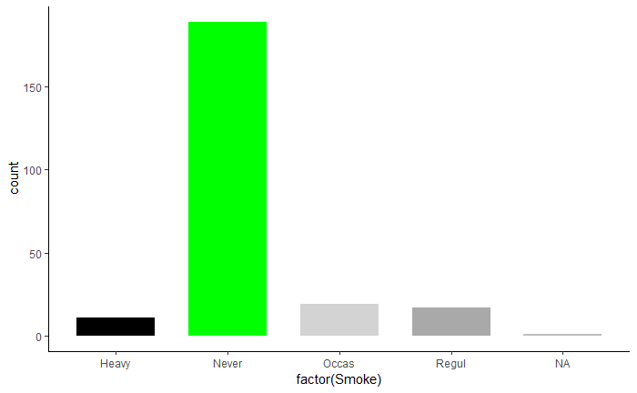

```r
ggplot(data = survey, aes(x = factor(Smoke))) +
  geom_bar(stat = "count", width = 0.7,
           fill = c("black", "green", "lightgrey", "darkgrey", "grey")) +
  theme_classic()
```

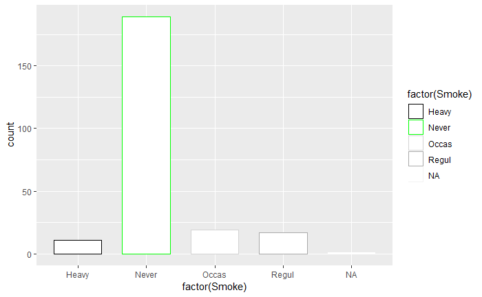

```r
ggplot(data = survey, aes(x = factor(Smoke), color = factor(Smoke))) +
  geom_bar(stat = "count", width = 0.7, fill = "white") +
  scale_color_manual(values=c("black", "green", "lightgrey", "darkgrey", "grey"))
```

Сега да разгледаме данните за тютюнопушенето в зависимост от пола:  
Данните за тютюнопушенето са качествени. Данните за пола, също са качествени.  
Честотната таблица

```r
table(survey$Sex, survey$Smoke)
```

```
         Heavy Never Occas Regul
  Female     5    99     9     5
  Male       6    89    10    12
```

Вероятността за едновременото сбъдване. Сумата от вероятностите в таблицата трябва да е 1.

```r
prop.table(table(survey$Sex, survey$Smoke))
```

```
          Heavy  Never  Occas  Regul
  Female 0.0213 0.4213 0.0383 0.0213
  Male   0.0255 0.3787 0.0426 0.0511
```

```r
sum(prop.table(table(survey$Sex, survey$Smoke)))
```

```
[1] 1
```

Условните веротности.  
Верояността да се случи събитието в колоната, при условие, че се е случило събитието в реда. Вероятностите в реда трябва да се сумират до 1.

```r
prop.table(table(survey$Sex, survey$Smoke), 1)
```

```
          Heavy  Never  Occas  Regul
  Female 0.0424 0.8390 0.0763 0.0424
  Male   0.0513 0.7607 0.0855 0.1026
```

```r
sum(prop.table(table(survey$Sex, survey$Smoke), 1)[1, ])
```

```
[1] 1
```

```r
sum(prop.table(table(survey$Sex, survey$Smoke), 1)[2, ])
```

```
[1] 1
```

Верояността да се случи събитието в реда, при условие, че се е случило събитието в колоната. Вероятностите в колоната трябва да се сумират до 1.

```r
prop.table(table(survey$Sex, survey$Smoke), 2)
```

```
         Heavy Never Occas Regul
  Female 0.455 0.527 0.474 0.294
  Male   0.545 0.473 0.526 0.706
```

```r
sum(prop.table(table(survey$Sex, survey$Smoke), 2)[, 1])
```

```
[1] 1
```

```r
sum(prop.table(table(survey$Sex, survey$Smoke), 2)[, 2])
```

```
[1] 1
```

```r
sum(prop.table(table(survey$Sex, survey$Smoke), 2)[, 3])
```

```
[1] 1
```

```r
sum(prop.table(table(survey$Sex, survey$Smoke), 2)[, 4])
```

```
[1] 1
```

Можем да зададем до къде да е закръглянето

```r
options(digits = 16)
prop.table(table(survey$Sex, survey$Smoke))
```

```
                       Heavy               Never               Occas               Regul
  Female 0.02127659574468085 0.42127659574468085 0.03829787234042553 0.02127659574468085
  Male   0.02553191489361702 0.37872340425531914 0.04255319148936170 0.05106382978723404
```

```r
prop.table(table(survey$Sex, survey$Smoke), 1)
```

```
                       Heavy               Never               Occas               Regul
  Female 0.04237288135593220 0.83898305084745761 0.07627118644067797 0.04237288135593220
  Male   0.05128205128205128 0.76068376068376065 0.08547008547008547 0.10256410256410256
```

```r
prop.table(table(survey$Sex, survey$Smoke), 2)
```

```
                      Heavy              Never              Occas              Regul
  Female 0.4545454545454545 0.5265957446808510 0.4736842105263158 0.2941176470588235
  Male   0.5454545454545454 0.4734042553191489 0.5263157894736842 0.7058823529411765
```

Барплот (Barplot)

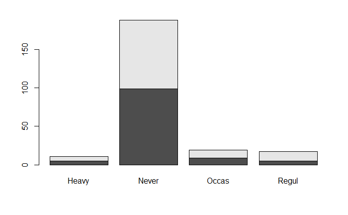

```r
barplot(table(survey$Sex, survey$Smoke))
```

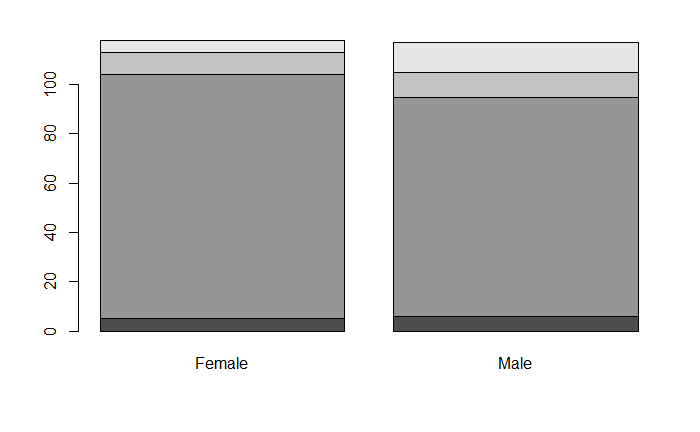

```r
barplot(table(survey$Smoke, survey$Sex))
```

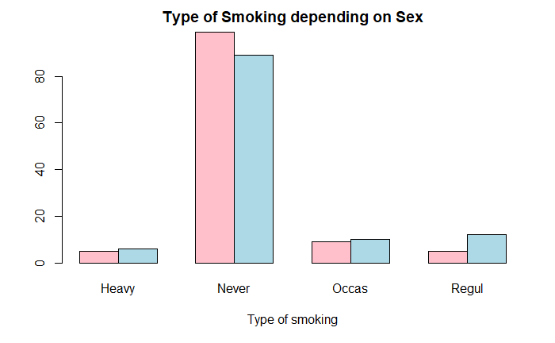

```r
barplot(table(survey$Sex, survey$Smoke),
        main = "Type of Smoking depending on Sex",
        names.arg = c("Heavy", "Never", "Occas", "Regul"),
        beside = TRUE,
        col = c("Pink", "lightblue"),
        xlab = "Type of smoking")
```

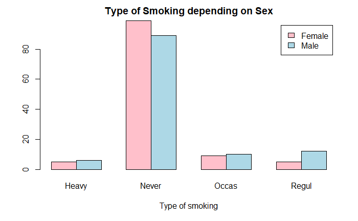

```r
barplot(table(survey$Sex, survey$Smoke),
        main = "Type of Smoking depending on Sex",
        names.arg = c("Heavy", "Never", "Occas", "Regul"),
        legend.text = TRUE,
        beside = TRUE,
        col = c("Pink", "lightblue"),
        xlab = "Type of smoking")
```

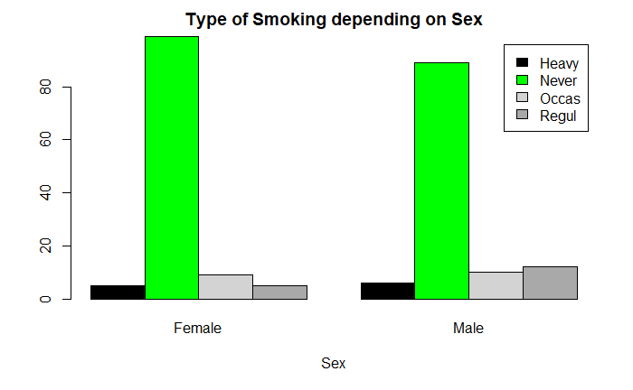

```r
barplot(table(survey$Smoke, survey$Sex),
        main = "Type of Smoking depending on Sex",
        names.arg = c("Female", "Male"),
        legend.text = TRUE,
        beside = TRUE,
        col = c("Black", "Green", "lightgrey", "darkgrey"),
        xlab = "Sex")
```

## Задача 3

Пресметнете оценки - средно, медиана, квартили, стандартно отклонение и т.н. за височината на студентите. Направете отделни изчисления за мъжете и за жените. Каква част от студентите се различават от средната височина с неповече от едно стандартно отклонение?  
Височината на студентите. Виждаме, че имаме много NA и трябва да внимаваме с тях.

```r
survey$Height
```

```
  [1] 173.00 177.80     NA 160.00 165.00 172.72 182.88 157.00 175.00 167.00 156.20     NA 155.00
 [14] 155.00     NA 156.00 157.00 182.88 190.50 177.00 190.50 180.34 180.34 184.00     NA     NA
 [27] 172.72 175.26     NA 167.00     NA 180.00 166.40 180.00     NA 190.00 168.00 182.50 185.00
 [40] 171.00 169.00 154.94 172.00 176.50 180.34 180.34 180.00 170.00 168.00 165.00 200.00 190.00
 [53] 170.18 179.00 182.00 171.00 157.48     NA 177.80 175.26 187.00 167.64 178.00 170.00 164.00
 [66] 183.00 172.00     NA 180.00     NA 170.00 176.00 171.00 167.64 165.00 170.00 165.00 165.10
 [79] 165.10 185.42     NA 176.50     NA     NA 167.64 167.00 162.56 170.00 179.00     NA 183.00
 [92]     NA 165.00 168.00 179.00     NA 190.00 166.50 165.00 175.26 187.00 170.00 159.00 175.00
[105] 163.00 170.00 172.00     NA 180.00 180.34 175.00 190.50 170.18 185.00 162.56 158.00 159.00
[118] 193.04 171.00 184.00     NA 177.00 172.00 180.00 175.26 180.34 172.72 178.50 157.00 152.00
[131] 187.96 178.00     NA 160.02 175.26 189.00 172.00 182.88 170.00 167.00 175.00 165.00 172.72
[144] 180.00 172.00 185.00 187.96 185.42 165.00 164.00 195.00 165.00 152.40 172.72 180.34 173.00
[157]     NA 167.64 187.96 187.00 167.00 168.00 191.80 169.20 177.00 168.00 170.00 160.02 189.00
[170] 180.34 168.00 182.88     NA 165.00 157.48 170.00 172.72 164.00     NA 162.56 172.00 165.10
[183] 162.50 170.00 175.00 168.00 163.00 165.00 173.00 196.00 179.10 180.00 176.00 160.02 157.48
[196] 165.00 170.18 154.94 170.00 164.00 167.00 174.00     NA 160.00 179.10 168.00 153.50 160.00
[209] 165.00 171.50 160.00 163.00     NA 165.00 168.90 170.00     NA 185.00 173.00 188.00 171.00
[222] 167.64 162.56 150.00     NA     NA 170.18 185.00 167.00 185.00 169.00 180.34 165.10 160.00
[235] 170.00 183.00 168.50
```

Най-ниският студент е с височина:

```r
min(survey$Height, na.rm = TRUE)
```

```
[1] 150
```

Най-високият студент е с височина:

```r
max(survey$Height, na.rm = TRUE)
```

```
[1] 200
```

Средната височина на студентите:

```r
mean(survey$Height, na.rm = TRUE)
```

```
[1] 172.3808612440191
```

Медианата на височините:

```r
median(survey$Height, na.rm = TRUE)
```

```
[1] 171
```

Първия квартил

```r
quantile(survey$Height, 0.25, na.rm = TRUE)
```

```
25%
165
```

Третия квартил

```r
quantile(survey$Height, 0.75, na.rm = TRUE)
```

```
75%
180
```

Дисперсията

```r
var(survey$Height, na.rm = TRUE)
```

```
[1] 96.9738011777696
```

Стандартното отклонение на височините

```r
sd(survey$Height, na.rm = TRUE)
```

```
[1] 9.847527668291651
```

Range:  
R = max - min

```r
max(survey$Height, na.rm = TRUE) - min(survey$Height, na.rm = TRUE)
```

```
[1] 50
```

IQR (Интерквартилен размах)

```r
IQR(survey$Height, na.rm = TRUE)
```

```
[1] 15
```

Min 1st_Q Median Mean 3rd_Q Max NA

```r
summary(survey$Height)
```

```
         Min.       1st Qu.        Median          Mean       3rd Qu.          Max.          NA's
150.000000000 165.000000000 171.000000000 172.380861244 180.000000000 200.000000000            28
```

Min H_lower Median H_upper Max

```r
fivenum(survey$Height)
```

```
[1] 150 165 171 180 200
```

Отделни изчисления за мъжете и жените

```r
summary(survey$Height[survey$Sex == "Male"])
```

```
          Min.        1st Qu.         Median           Mean        3rd Qu.           Max.
154.9400000000 172.7900000000 180.0000000000 178.8260377358 185.0000000000 200.0000000000
          NA's
            13
```

```r
summary(survey$Height[survey$Sex == "Female"])
```

```
          Min.        1st Qu.         Median           Mean        3rd Qu.           Max.
150.0000000000 162.5600000000 166.7500000000 165.6866666667 170.0000000000 180.3400000000
          NA's
            17
```

Каква част от студентите се различават от средната височина с неповече от едно 1 стандартно отклонение?  
т.е. наблюдението да попадне в интервала  
[mean - sd, mean + sd]  
mean - sd < y < mean + sd  
- sd < y - mean < sd  
|y - mean| < sd

```r
clean.hight = survey$Height[!is.na(survey$Height)]
mean = mean(clean.hight)
sd = sd(clean.hight)
sum(abs(clean.hight - mean) < sd) / length(clean.hight)
```

```
[1] 0.6842105263157895
```

## Задача 4

Представете графично височината на студентите.

Височината на студентите е количествена променлива. Min 1st_Q Median Mean 3rd_Q Max NA

```r
summary(survey$Height)
```

```
         Min.       1st Qu.        Median          Mean       3rd Qu.          Max.          NA's
150.000000000 165.000000000 171.000000000 172.380861244 180.000000000 200.000000000            28
```

Min H_lower Median H_upper Max

```r
fivenum(survey$Height)
```

```
[1] 150 165 171 180 200
```

```r
clean.height = survey$Height[!is.na(survey$Height)]
```

Хистограма

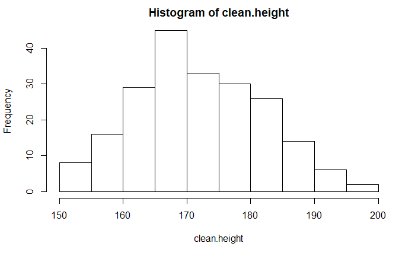

```r
hist(clean.height)
```

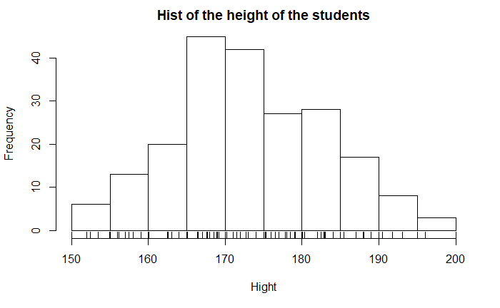

```r
hist(clean.height,
     right = FALSE,
     main = "Hist of the height of the students",
     xlab = "Hight")
rug(jitter(clean.height))
```

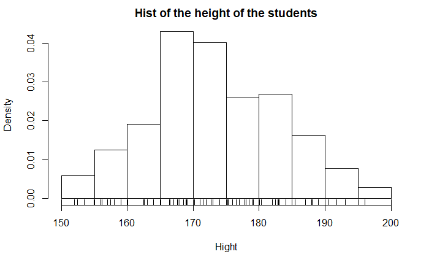

```r
hist(clean.height,
     right = FALSE,
     main = "Hist of the height of the students",
     xlab = "Hight",
     probability = TRUE)
rug(jitter(clean.height))
```

Кутия с мустачки

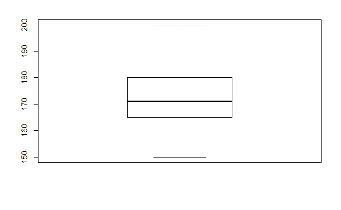

```r
boxplot(clean.height)
```

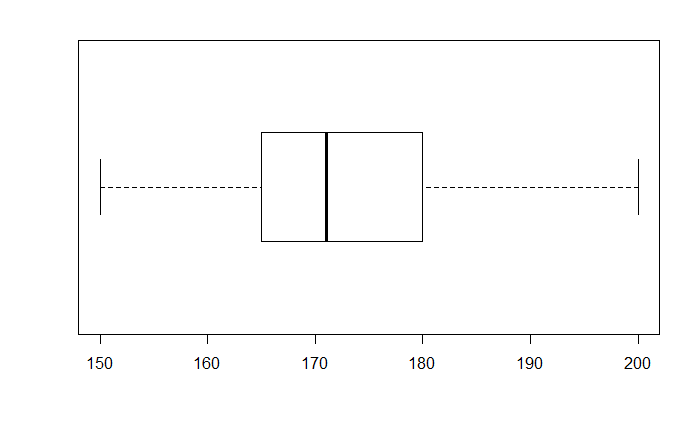

```r
boxplot(clean.height, horizontal = TRUE)
```

Хистограма и курия с мустачки на една графика

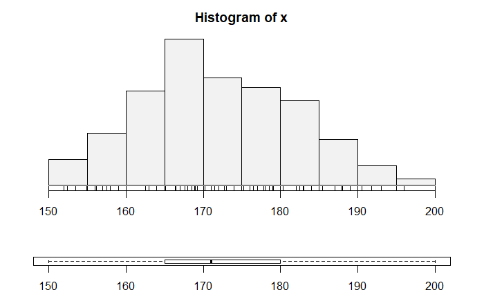

```r
library(UsingR)
simple.hist.and.boxplot(clean.height)
```

Хистограма и полигон на една графика

```r
min.height = min(clean.height); min.height
```

```
[1] 150
```

```r
max.height = max(clean.height); max.height
```

```
[1] 200
```

```r
breaks = seq(min.height, max.height, by = 10); breaks
```

```
[1] 150 160 170 180 190 200
```

```r
survey$height.cut = cut(survey$Height, breaks, right = FALSE)
View(survey)
table(survey$Height.cut)
```

```
< table of extent 0 >
```

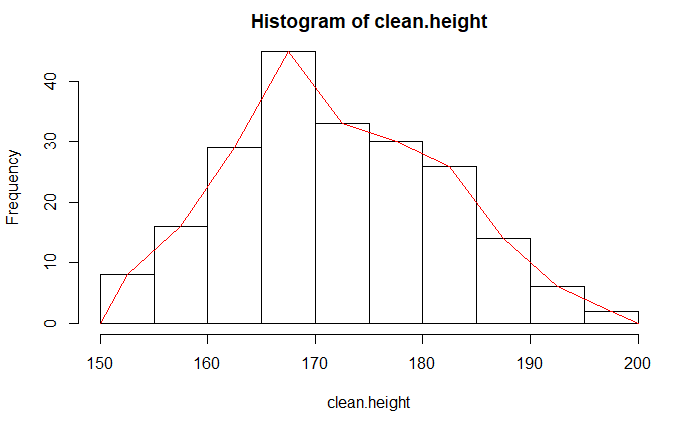

```r
tmp = hist(clean.height)
lines(c(min(tmp$breaks), tmp$mids, max(tmp$breaks)), c(0, tmp$counts, 0), type = "l", col = "red")
```

Хистограма и плътност

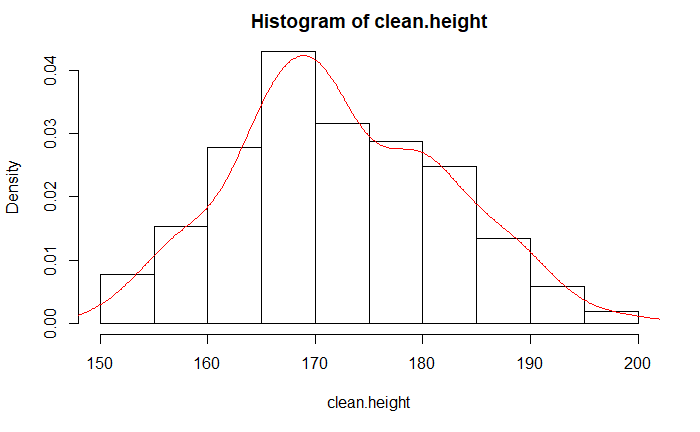

```r
clean.height = survey$Height[!is.na(survey$Height)]
hist(clean.height, 15, prob = TRUE)
lines(density(clean.height, bw = "SJ"), col = 'red')
```

Нарисучайте графика на височината на студентите, разделена по пол.

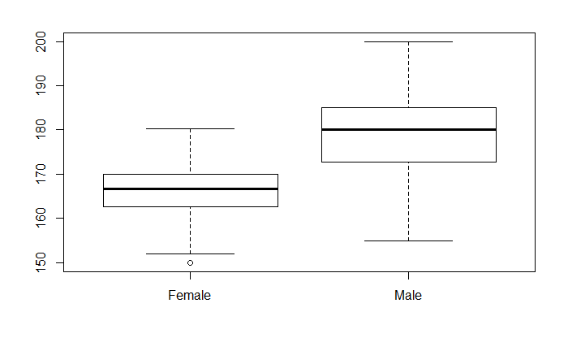

```r
boxplot(survey$Height ~ survey$Sex)
```

## Задача 5

Направете хистограма за пулса на студентите. Добавете плътността.

```r
names(survey)
```

```
 [1] "Sex"        "Wr.Hnd"     "NW.Hnd"     "W.Hnd"      "Fold"       "Pulse"      "Clap"
 [8] "Exer"       "Smoke"      "Height"     "M.I"        "Age"        "height.cut"
```

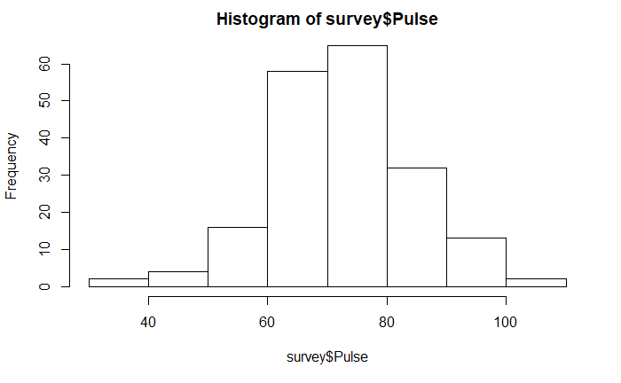

```r
hist(survey$Pulse)
```

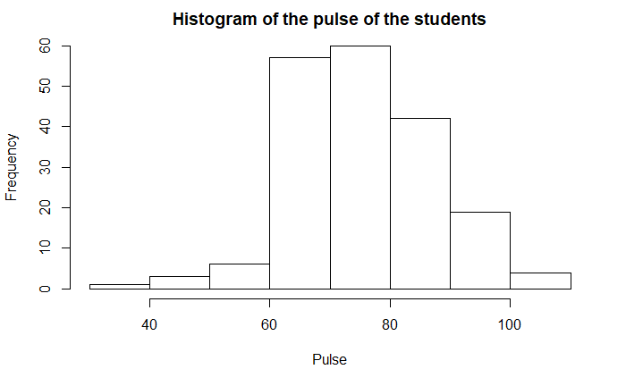

```r
hist(survey$Pulse,
     right = FALSE,
     main = "Histogram of the pulse of the students",
     xlab = "Pulse" )
```

Хистограма на относителните честоти

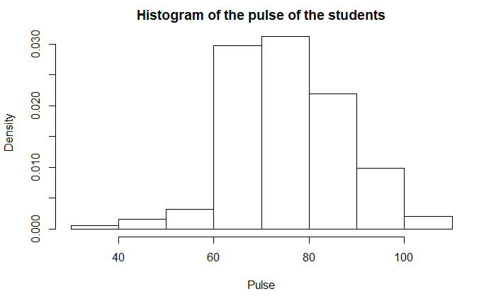

```r
hist(survey$Pulse,
     right = FALSE,
     main = "Histogram of the pulse of the students",
     xlab = "Pulse",
     probability = TRUE)
```

Хистограма и плътност

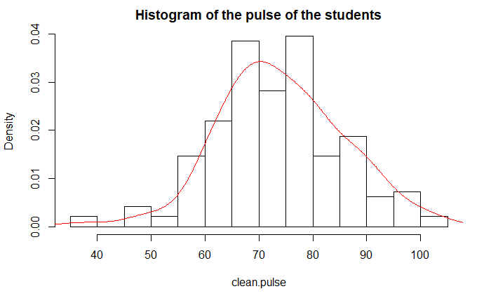

```r
clean.pulse = survey$Pulse[!is.na(survey$Pulse)]
hist(clean.pulse, breaks = 15, prob = TRUE, main = "Histogram of the pulse of the students")
lines(density(clean.pulse, bw = "SJ"), col = 'red')
```

## Задача 6

Разделете студентите според възрастта им на три групи: А - до 20г, B- от 20 до 25 и C - над 25. Представете графично. Направете таблица за разпределението на пушачите в различните възрасти, представете графично.

```r
breaks = c(min(survey$Age), 20, 25, max(survey$Age)); breaks
```

```
[1] 16.75 20.00 25.00 73.00
```

```r
survey$аge.cut = cut(survey$Age, breaks, right = FALSE)
View(survey)
table(survey$аge.cut)
```

```
[16.8,20)   [20,25)   [25,73)
      171        47        18
```

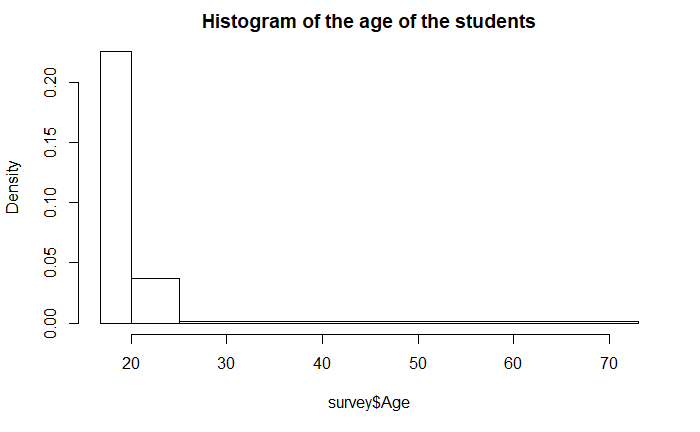

```r
hist(survey$Age,
     main = "Histogram of the age of the students",
     breaks = breaks)
```

```r
table(survey$аge.cut,survey$Smoke)
```

```
            Heavy Never Occas Regul
  [16.8,20)     5   138    16    11
  [20,25)       5    37     1     4
  [25,73)       1    13     2     2
```

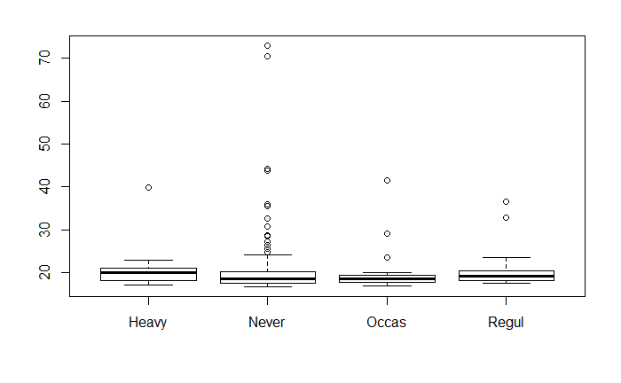

```r
boxplot(survey$Age ~ survey$Smoke)
```